# Estimating bluetongue outbreaks in Italy using capture–recapture

Andrea Tonelli

2026-01-08

## Introduction

Bluetongue is a vector-borne viral disease affecting domestic and wild ruminants, caused by the Bluetongue virus (BTV) and transmitted mainly by Culicoides biting midges. In recent years, bluetongue has re-emerged in several European countries, including Italy, posing significant challenges for animal health surveillance systems.

In Italy, information on bluetongue outbreaks is collected through multiple surveillance channels. This report focuses on two data sources (assumed to be independent in this case study):

The National Veterinary Epidemiological Bulletin (BENV), which collects officially notified clinical outbreaks.

EMPRES-i (FAO), a global animal disease information system that aggregates outbreak reports from multiple official and unofficial sources.

Because no single system can be assumed to capture all outbreaks, combining these sources can provide a more realistic estimate of the true number of bluetongue outbreaks. To this end, a capture–recapture approach based on the Chapman estimator was applied.

#### Spatial distribution of reported outbreaks

The maps below show the regional distribution of bluetongue outbreaks reported by each surveillance system in 2024 and 2025.

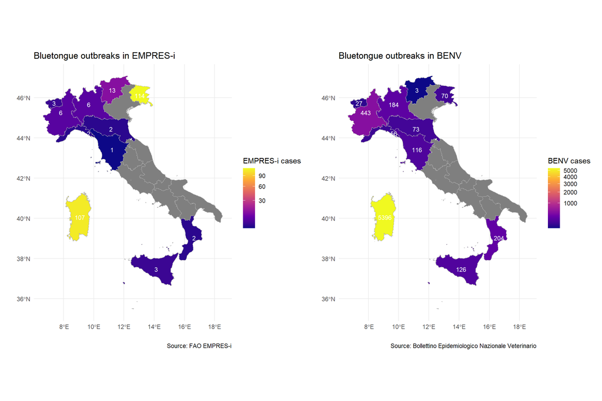

Although the overall spatial patterns are similar, noticeable differences emerge across regions, suggesting incomplete and partially overlapping reporting.

#### Overlap between surveillance systems

The overlap between EMPRES-i and BENV outbreak records is illustrated using a Venn diagram.

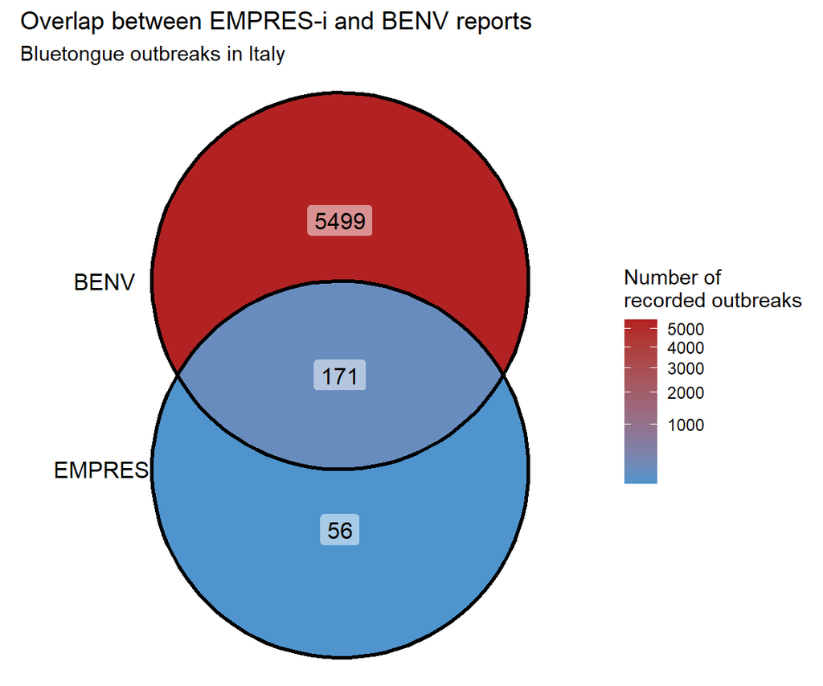

Only a subset of outbreaks is shared between the two systems, supporting the use of capture–recapture methods to estimate the unobserved component.

## Methods

#### Capture–recapture framework

A two-source capture–recapture model was applied at the regional level, using the Chapman estimator, an unbiased correction of the Lincoln–Petersen estimator for small samples.

Let $n_1$ and $n_2$ denote the number of outbreaks captured by EMPRES-i and BENV, respectively; while $m$ is the number of outbreaks observed by both systems.

The Chapman estimator of the total number of outbreaks $\hat{N}$ is:
$$\hat{N} = \frac{(n_1 + 1)(n_2 + 1)}{(m + 1)} - 1$$
The variance is estimated as:
$$\mathrm{Var}(\hat{N}) =
\frac{(n_1 + 1)(n_2 + 1)(n_1 - m)(n_2 - m)}
{(m + 1)^2 (m + 2)}$$

From this, 95% confidence intervals were computed assuming approximate normality.

#### Assumptions

The capture–recapture approach relies on some key assumptions:

Independence of sources: the probability of an outbreak being reported in one system is independent of its reporting in the other.

Homogeneous capture probability within each region.

## Results

#### Estimated number of outbreaks

The map below shows the estimated total number of bluetongue outbreaks by region obtained using the Chapman estimator.

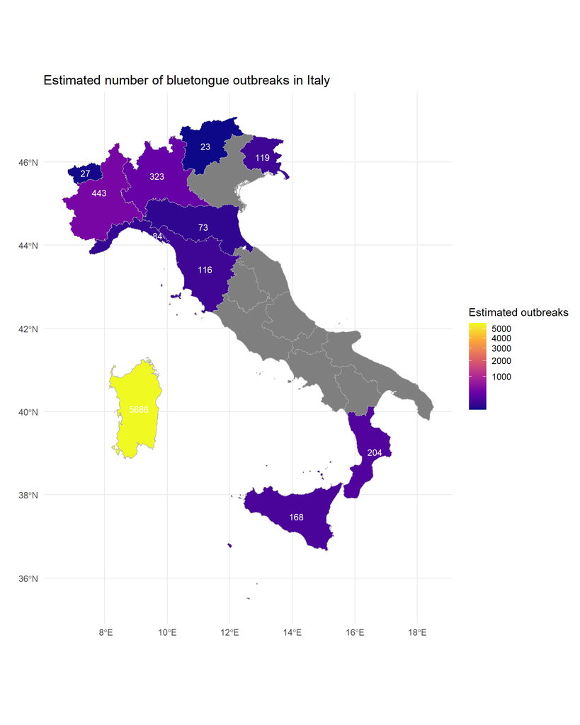

The estimated number of outbreaks indicates potentially major blindspots in EMPRES-i reporting of bluetongue in Italy.

#### Regional estimates and confidence intervals

The table below summarizes, for each region, the number of outbreaks recorded by each system, their overlap, the Chapman estimate, and the corresponding 95% confidence interval.

Capture–recapture estimates of bluetongue outbreaks by region

| Regione | empresi | benv | overlap | CI_low | CI_high | estimate |
| --- | --- | --- | --- | --- | --- | --- |
| VALLE D’AOSTA | 3 | 27 | 3 | 27.0 | 27.0 | 27.0 |
| SARDEGNA | 97 | 5396 | 92 | 5428.7 | 5943.6 | 5686.2 |
| FRIULI VENEZIA GIULIA | 100 | 70 | 59 | 111.0 | 126.0 | 118.5 |
| LOMBARDIA | 6 | 184 | 3 | 139.0 | 506.5 | 322.8 |
| EMILIA ROMAGNA | 2 | 73 | 2 | 73.0 | 73.0 | 73.0 |
| SICILIA | 3 | 126 | 2 | 86.3 | 250.3 | 168.3 |
| PIEMONTE | 6 | 443 | 6 | 443.0 | 443.0 | 443.0 |
| CALABRIA | 2 | 204 | 2 | 204.0 | 204.0 | 204.0 |
| TOSCANA | 1 | 116 | 1 | 116.0 | 116.0 | 116.0 |
| LIGURIA | 2 | 56 | 1 | 29.6 | 139.4 | 84.5 |

Uncertainty varies substantially across regions, largely reflecting differences in sample size and overlap between sources.

## Conclusions

This analysis shows that combining independent data sources through a capture–recapture framework can provide a more complete picture of outbreak occurrences than either system alone. The results suggest that a non-negligible number of outbreaks may remain unreported in individual surveillance systems.

While the Chapman estimator offers a simple and transparent approach, results should be interpreted cautiously given the underlying assumptions, particularly source independence. Nevertheless, capture–recapture methods represent a valuable tool for strengthening veterinary surveillance and supporting evidence-based animal health decision-making.